# Case Study 3: Minecraft Zombie’s Weapon Comparison

Wil Jones

# Introduction

This study tested whether weapon type affected performance in a Minecraft zombie arena. The response variable was damage absorbed per trial, recorded in Minecraft damage-stat units as `DamageTaken`. Lower values mean the player absorbed less damage while fighting the same group of `64` zombies, so smaller responses indicate better performance. The treatment factor was weapon type with three levels: sword, axe, and trident. The blocking factor was play session with four levels, Sessions 1 through 4. The test was a randomized complete block ANOVA with session used to remove potential variation that might come from fatigue, rhythm, or small gameplay differences.

[figure not shown]

Equipment used for the Minecraft weapon study

[figure not shown]

Player character used in the Minecraft weapon study aka… me

## Methods

### Hypotheses

The significance level for the ANOVA was set to $\alpha = 0.05$.

For weapon type:

$H_0: \mu_{sword} = \mu_{axe} = \mu_{trident}$

$H_A$: at least one mean damage-absorbed value differs among the three weapons.

For session block effects:

$H_0: \mu_{Session\ 1} = \mu_{Session\ 2} = \mu_{Session\ 3} = \mu_{Session\ 4}$

$H_A$: at least one session mean differs.

The session effect was included as a block to absorb potential variation across sessions rather than as the main scientific question. Because there is only one observation for each weapon-session combination, the model does not separately test a weapon-by-session interaction.

### Design

This was a randomized complete block design with three weapon treatments and four blocks. In each session, the player completed one sword trial, one axe trial, and one trident trial, giving a total of 12 trials. The arena, world settings, armor with Protection IV enchantments, difficulty, zombie count, and starting setup were held constant so that weapon choice was the main planned source of treatment variation.

```r
DT::datatable(
  ord.tb,
  colnames = c("Session", "Order", "Weapon", "Damage absorbed"),
  options = list(pageLength = 12, lengthChange = FALSE)
)
```

|  | Session | Order | Weapon | Damage absorbed |
| --- | --- | --- | --- | --- |
| 1 | Session 1 | 1 | sword | 53.2 |
| 2 | Session 1 | 2 | axe | 42.84 |
| 3 | Session 1 | 3 | trident | 47.98 |
| 4 | Session 2 | 1 | trident | 34 |
| 5 | Session 2 | 2 | axe | 68.38 |
| 6 | Session 2 | 3 | sword | 21 |
| 7 | Session 3 | 1 | sword | 39.7 |
| 8 | Session 3 | 2 | trident | 56.5 |
| 9 | Session 3 | 3 | axe | 37.5 |
| 10 | Session 4 | 1 | axe | 24.7 |

[output cut: 2 more lines]

### Procedure

1. Use the same enclosed Minecraft arena, same world, the same Protection IV armor, the same difficulty setting `hard mode`, and the same zombie spawn procedure for every trial.

[figure not shown]

Minecraft zombie arena used for the trials

2. At the start of each trial, set the time to night, prepare the same starting conditions, and spawn 64 zombies into the arena.

[figure not shown]

Resetting zombies and setting it to night between each run

3. Randomize the order of sword, axe, and trident within each session so weapon performance is not mixed up with warm-up, fatigue, or changing focus.
4. Fight until all 64 zombies are defeated using only the assigned weapon for that trial.

[figure not shown]

Fighting for my life without dying

5. Record the cumulative damage statistic after each run, then convert it to trial-specific damage absorbed so each observation represents one weapon-session combination.

[figure not shown]

Checking the stats …

6. Reset the arena before the next weapon trial in that session.

### Randomization And Bias

The randomized part of the design was the within-session weapon order, represented by the `Order` column in the file. That step helps protect the weapon comparison from order effects. The parts that were not randomized were the player, arena, world, and general test setup. Those fixed choices improve consistency, but they also introduce possible bias because the results reflect one player in one arena rather than all Minecraft combat situations. In addition, if session-level practice or tiredness changed over time, those effects could still influence the data, which is why session was treated as a block.

### Variance And Limits

Important uncontrolled variation could still come from small differences in movement, timing, zombie pathing, aim, and in-game crowding. Blocking by session helps account for some of that run-to-run noise, but with only one observation per weapon inside each session, the design does not allow a separate test of a weapon-by-session interaction. That means the ANOVA assumes the weapon differences are fairly consistent across sessions.

## Analysis

### Data Summary

The trident had the largest sample mean damage absorbed at 46.94, while the sword had the smallest at 39.42. Because lower damage absorbed is better here, the sword looked best on raw averages, but the spreads were wide enough that these visible differences needed formal ANOVA confirmation.

```r
kable(w.sum, digits = 2, col.names = c("Weapon", "n", "Mean", "SD", "Min", "Max")) |>
  kable_styling(full_width = TRUE)
```

| Weapon | n | Mean | SD | Min | Max |
| --- | --- | --- | --- | --- | --- |
| sword | 4 | 39.42 | 13.52 | 21.0 | 53.20 |
| axe | 4 | 43.35 | 18.34 | 24.7 | 68.38 |
| trident | 4 | 46.94 | 9.41 | 34.0 | 56.50 |

```r
kable(s.sum, digits = 2, col.names = c("Session", "n", "Mean", "SD", "Min", "Max")) |>
  kable_styling(full_width = TRUE)
```

| Session | n | Mean | SD | Min | Max |
| --- | --- | --- | --- | --- | --- |
| Session 1 | 3 | 48.01 | 5.18 | 42.84 | 53.20 |
| Session 2 | 3 | 41.13 | 24.48 | 21.00 | 68.38 |
| Session 3 | 3 | 44.57 | 10.39 | 37.50 | 56.50 |
| Session 4 | 3 | 39.27 | 12.91 | 24.70 | 49.30 |

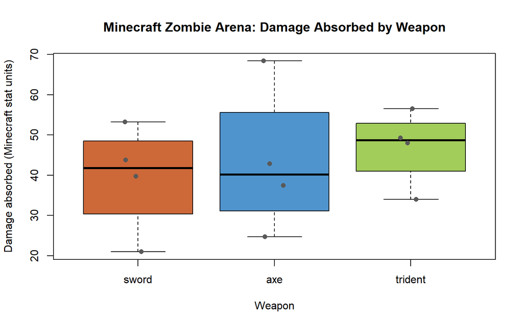

```r
boxplot(y ~ Weapon, data = d.df,
  main = "Minecraft Zombie Arena: Damage Absorbed by Weapon",
  xlab = "Weapon", ylab = "Damage absorbed (Minecraft stat units)",
        col = weapon.cols)
stripchart(y ~ Weapon, data = d.df, add = TRUE, vertical = TRUE,
           method = "jitter", pch = 16, col = "gray35")
```

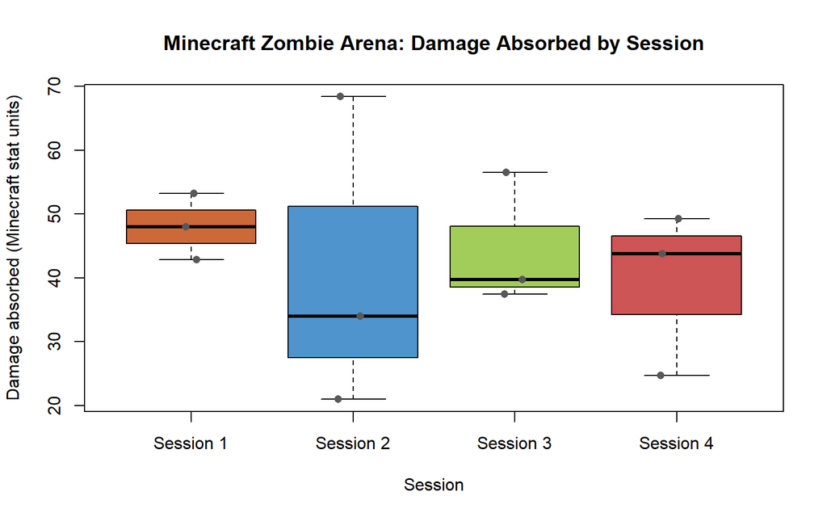

```r
boxplot(y ~ Session, data = d.df,
  main = "Minecraft Zombie Arena: Damage Absorbed by Session",
  xlab = "Session", ylab = "Damage absorbed (Minecraft stat units)",
  col = session.cols)
stripchart(y ~ Session, data = d.df, add = TRUE, vertical = TRUE,
           method = "jitter", pch = 16, col = "gray35")
```

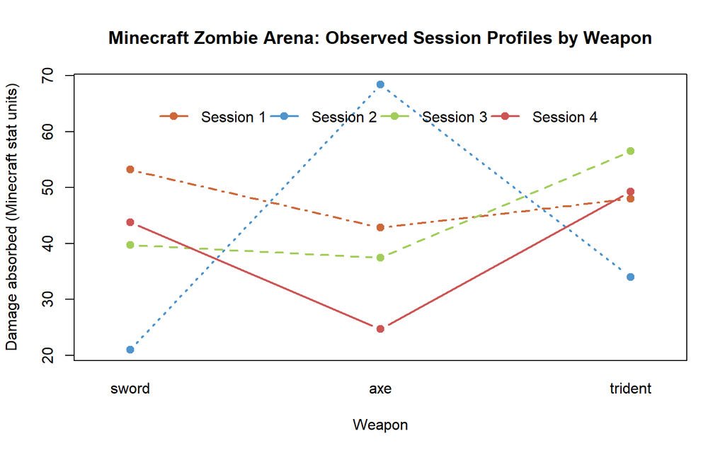

```r
interaction.plot(d.df$Weapon, d.df$Session, d.df$y,
                 type = "b", pch = 19, lwd = 2,
                 col = session.cols,
                 xlab = "Weapon", ylab = "Damage absorbed (Minecraft stat units)",
                 legend = FALSE,
                 main = "Minecraft Zombie Arena: Observed Session Profiles by Weapon")
legend("top",
       legend = levels(d.df$Session),
       title = "",
       horiz = TRUE,
       lty = 1,
       lwd = 2,
       pch = 19,
      col = session.cols,
       bty = "n",
       inset = 0.02)
```

### Assumptions

For the blocked ANOVA, I checked the usual residual assumptions: approximately normal errors, roughly constant variance, and independence across trials. The residual vs fitted plot did not show a strong megaphone pattern, so a log transformation was not needed. The Q-Q plot looked acceptable for such a small sample, and the residuals plotted against trial order did not show an obvious time trend. The Shapiro-Wilk test on the model residuals gave $p = 0.454$, which does not break from normality.

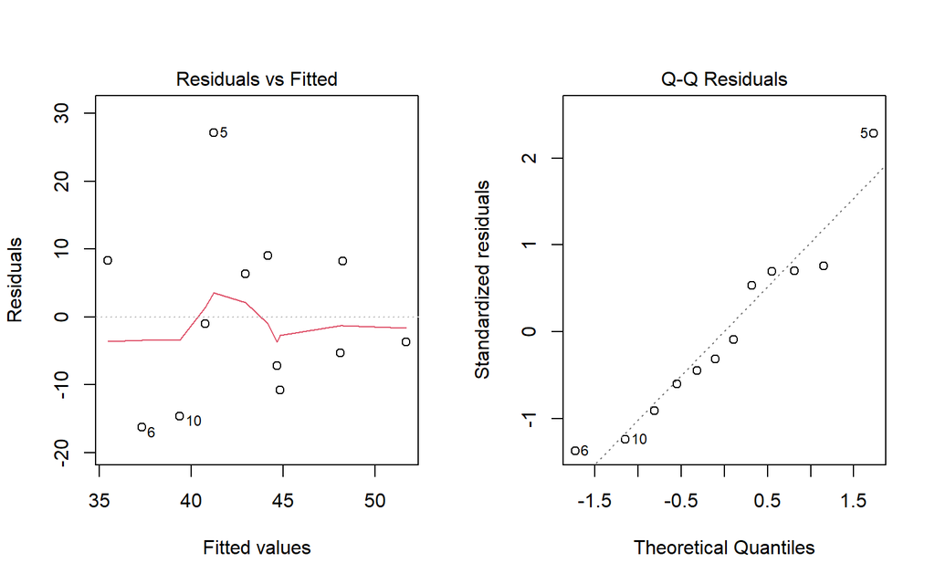

```r
op <- par(mfrow = c(1, 2))
plot(b.fit, which = 1)
plot(b.fit, which = 2)
```

```r
par(op)
```

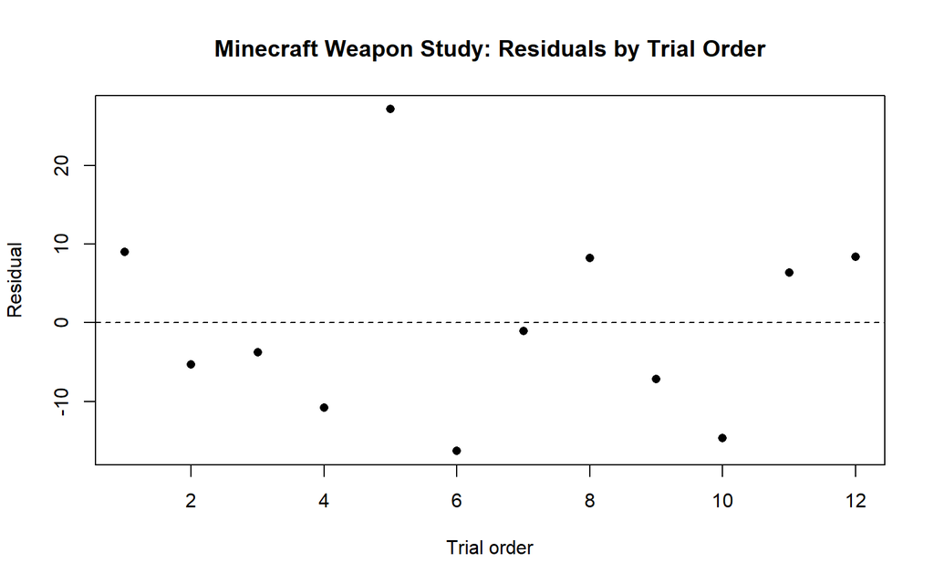

```r
plot(d.df$trial_id, resid(b.fit),
  main = "Minecraft Weapon Study: Residuals by Trial Order",
     xlab = "Trial order", ylab = "Residual",
     pch = 16)
abline(h = 0, lty = 2)
```

### ANOVA

Because this is a randomized complete block design with one observation for each weapon in each session. The set up includes sessions as a block and weapon as the treatment factor. The weapon effect was not statistically significant, $F(2, 6) = 0.2$, $p = 0.823$. The block effect was also not statistically significant, $F(3, 6) = 0.16$, $p = 0.920$. In other words, after accounting for session, the data do not provide strong evidence that sword, axe, and trident differ in mean damage absorbed in this experiment.

```r
kable(b.aov, digits = 3, col.names = c("Term", "Df", "Sum Sq", "Mean Sq", "F", "p")) |>
  kable_styling(full_width = TRUE)
```

| Term | Df | Sum Sq | Mean Sq | F | p |
| --- | --- | --- | --- | --- | --- |
| Session | 3 | 134.204 | 44.735 | 0.159 | 0.920 |
| Weapon | 2 | 113.178 | 56.589 | 0.201 | 0.823 |
| Residuals | 6 | 1688.538 | 281.423 | NA | NA |

### Follow-Up

Because the overall weapon test was not significant at $\alpha = 0.05$, I did not run multiple comparisons. Reporting pairwise differences after a clearly non-significant omnibus test would add noise without adding defensible evidence. On raw means alone, the sword had the smallest observed damage absorbed and the trident had the largest, but those average gaps were small relative to the within-weapon variability.

# Conclusion

This experiment did not find a statistically clear weapon effect in the Minecraft zombie arena. Within the four blocked sessions, the sword, axe, and trident produced similar damage-absorbed outcomes once normal run-to-run variation was taken into account. The sword had the best raw average, but not by enough to conclude that it truly outperformed the other weapons in this dataset. A stronger follow-up study would add more sessions, keep the same blocking strategy, and possibly collect a second response such as completion time so weapon performance can be judged from more than one angle.